# My answers

Hamed Vaheb

2021-11-19

> This practical aims at performing exploratory plots and how-to build layer by layer to be familiar with the grammar of graphics.

##### Those kind of questions are optional

# Scatter plots of penguins

The `penguins` dataset is provided by the `palmerpenguins` R package. As for every function, most data-sets shipped with a package contain also a useful help page (`?`).

##### If not done already, install the package `palmerpenguins` and load it.

```r
# I've already loaded the package
glimpse(penguins)
```

```
## Rows: 344
## Columns: 8
## $ species           <fct> Adelie, Adelie, Adelie, Adelie, Adelie, Adelie, Adel…
## $ island            <fct> Torgersen, Torgersen, Torgersen, Torgersen, Torgerse…
## $ bill_length_mm    <dbl> 39.1, 39.5, 40.3, NA, 36.7, 39.3, 38.9, 39.2, 34.1, …
## $ bill_depth_mm     <dbl> 18.7, 17.4, 18.0, NA, 19.3, 20.6, 17.8, 19.6, 18.1, …
## $ flipper_length_mm <int> 181, 186, 195, NA, 193, 190, 181, 195, 193, 190, 186…
## $ body_mass_g       <int> 3750, 3800, 3250, NA, 3450, 3650, 3625, 4675, 3475, …
## $ sex               <fct> male, female, female, NA, female, male, female, male…
## $ year              <int> 2007, 2007, 2007, 2007, 2007, 2007, 2007, 2007, 2007…
```

##### Plot the body mass on the *y* axis and the bill length on the *x* axis.

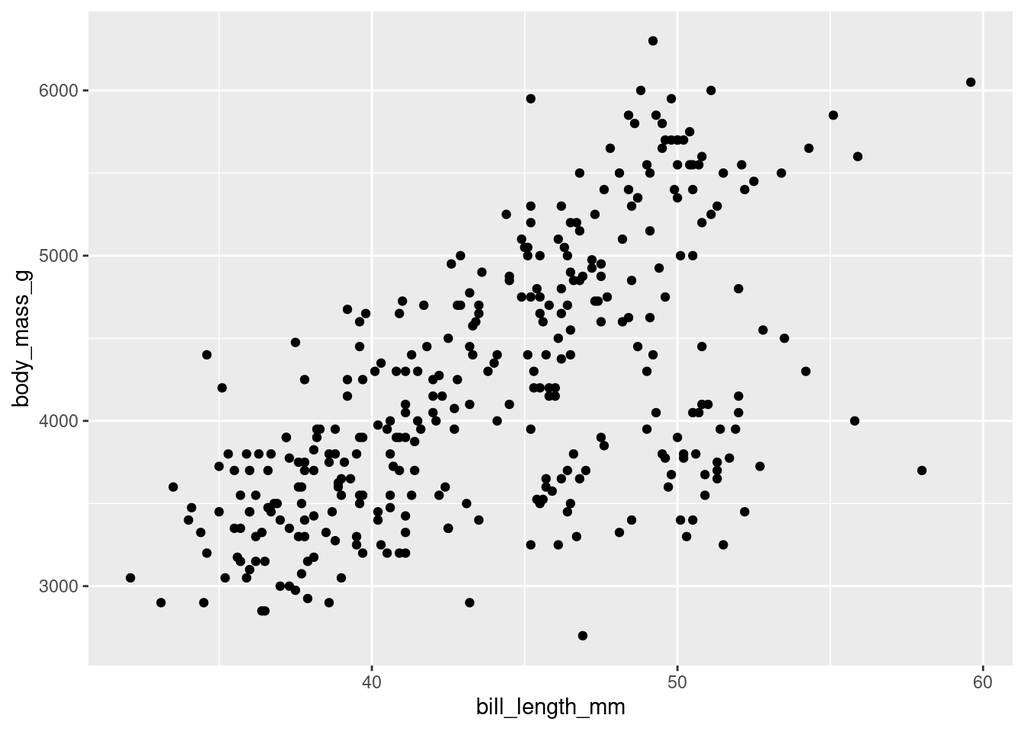

```r
# Write your answer here
ggplot(data = penguins) +
geom_point(mapping = aes(x = bill_length_mm,
                         y = body_mass_g))
```

##### Plot again the body mass on the *y* axis and the bill length on the *x* axis, but with colour by `species`

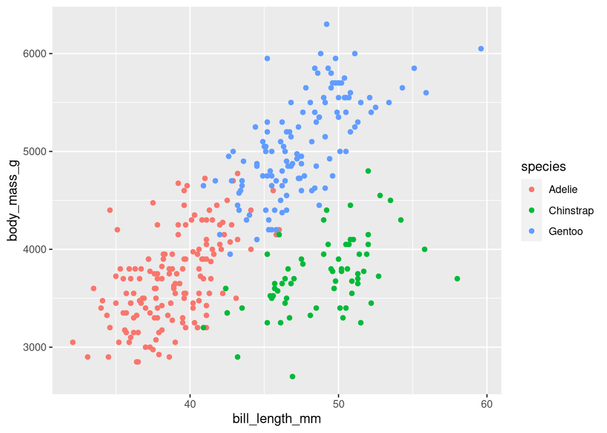

```r
# Write your answer here
ggplot(data = penguins) +
geom_point(mapping = aes(x = bill_length_mm,
                         y = body_mass_g,
                         colour = species))
```

##### The `geom_smooth()` layer can be used to add a trend line. Try to overlay it to your scatter plot.

by default `geom_smooth` is using a loess regression (< 1,000 points) and adds standard error intervals.

- The `method` argument can be used to change the regression to a linear one: `method = "lm"`
- to disable the ribbon of standard errors, set `se = FALSE`

Be careful where the aesthetics are located, so the trend linear lines are **also** colored per species.

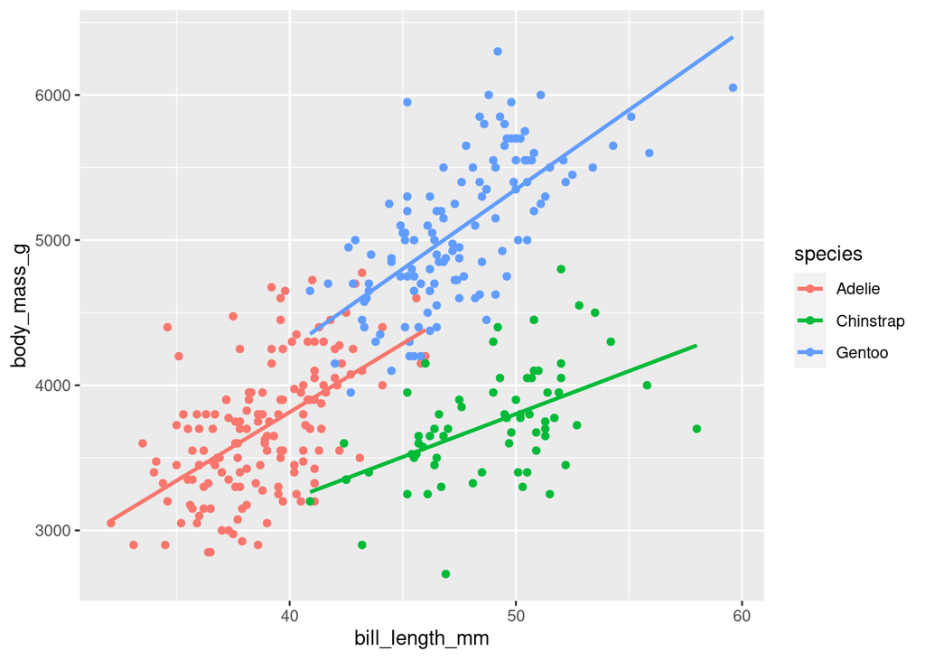

```r
# Write your answer here
ggplot(penguins,
aes(x = bill_length_mm,
    y = body_mass_g,
    colour = species)) +
geom_point() +
geom_smooth(method = "lm", se = FALSE,
            formula = 'y ~ x')
```

##### Adjust the aesthetics of point in order to

- the `shape` map to the originated `island`
- a fixed size of `3`
- a transparency of 40%

You should still have only 3 coloured linear trend lines. Otherwise check to which layer your are adding the aesthetic `shape`. Remember that fixed parameters are to be defined outside `aes()`

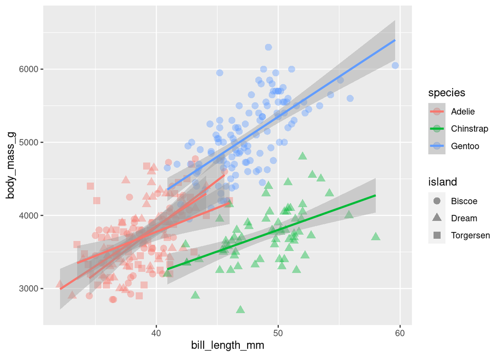

```r
# Write your answer here
ggplot(penguins,
aes(x = bill_length_mm,
y = body_mass_g,
shape = island,
colour = species)) +
geom_point(size = 3, alpha = 0.4) +
geom_smooth(method = "lm",
            formula = 'y ~ x')
```

##### Ajust the colour aesthetic to the `ggplot()` call to propagate it to both point and regression line.

Try the scale colour viridis for discrete scale (`scale_colour_viridis_d()`). Try to change the default theme to `theme_bw()`

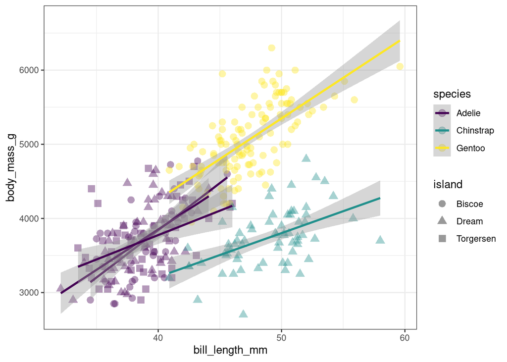

```r
# Write your answer here

ggplot(penguins,
aes(x = bill_length_mm,
    y = body_mass_g,
    shape = island,
    colour = species)) +
geom_point(size = 3, alpha = 0.4) +
geom_smooth(method = "lm",
            formula = 'y ~ x') +
scale_color_viridis_d() +
theme_bw()
```

```r
# Write your answer here
```

Remember that:

- all aesthetics defined in the `ggplot(aes())` command will be inherited by all following layers
- `aes()` of individual geoms are specific (and overwrite the global definition if present).
- `labs()` controls of plot annotations
- `theme()` allows to tweak the plot like `theme(plot.caption = element_text(face = "italic"))` to render in italic the caption

> This task is missing.

# Categorical data

We are going to use a dataset from the [TidyTuesday](https://github.com/rfordatascience/tidytuesday/) initiative. Several dataset about the theme **deforestation** on April 2021 were released, we will focus on the csv called `brazil_loss.csv`. The dataset columns are described in the linked [README](https://github.com/rfordatascience/tidytuesday/blob/master/data/2021/2021-04-06/readme.md) and the csv is directly available at this [url](https://raw.githubusercontent.com/rfordatascience/tidytuesday/master/data/2021/2021-04-06/brazil_loss.csv)

##### Load the `brazil_loss.csv` file, remove the 2 first columns (`entity` and `code` since it is all Brazil) and assign the name `brazil_loss`

Set the data type of `year` to `character()`

```r
# Write your answer here
brazil_url <- "https://raw.githubusercontent.com/rfordatascience/tidytuesday/master/data/2021/2021-04-06/brazil_loss.csv"

brazil <- readr::read_delim(brazil_url, show_col_types = FALSE) %>%
  select(-entity, -code)

glimpse(brazil)
```

```
## Rows: 13
## Columns: 12
## $ year                            <dbl> 2001, 2002, 2003, 2004, 2005, 2006, 20…
## $ commercial_crops                <dbl> 280000, 415000, 550000, 747000, 328000…
## $ flooding_due_to_dams            <dbl> 0, 79000, 0, 26000, 17000, 17000, 9000…
## $ natural_disturbances            <dbl> 0, 35000, 35000, 22000, 26000, 26000, …
## $ pasture                         <dbl> 1520000, 2568000, 2761000, 2564000, 26…
## $ selective_logging               <dbl> 96000, 96000, 149000, 131000, 140000, …
## $ fire                            <dbl> 26000, 114000, 44000, 79000, 393000, 7…
## $ mining                          <dbl> 9000, 9000, 0, 0, 0, 0, 9000, 9000, 0,…
## $ other_infrastructure            <dbl> 9000, 13000, 9000, 13000, 13000, 9000,…
## $ roads                           <dbl> 13000, 31000, 35000, 57000, 35000, 170…
## $ tree_plantations_including_palm <dbl> 44000, 44000, 26000, 92000, 52000, 260…
## $ small_scale_clearing            <dbl> 249000, 293000, 358000, 415000, 288000…
```

##### Is this dataset tidy?

```r
# Write your answer here

#the dataset has the variables in
#brazil[0,]
#as.character(unlist(brazil[1,]))

#
```

> This is not an acceptable answer.

##### Pivot the deforestation reasons (columns `commercial_crops` to `small_scale_clearing`) to the long format. Values are areas in hectares (`area_ha` is a good column name). Save as `brazil_loss_long`

```r
# Write your answer here
brazil %>%
  pivot_longer(-c("year"), names_to = "deforestation_reasons",
               values_to = "area_ha") -> brazil_loss_long

 brazil_loss_long
```

```
## # A tibble: 143 × 3
##     year deforestation_reasons           area_ha
##    <dbl> <chr>                             <dbl>
##  1  2001 commercial_crops                 280000
##  2  2001 flooding_due_to_dams                  0
##  3  2001 natural_disturbances                  0
##  4  2001 pasture                         1520000
##  5  2001 selective_logging                 96000
##  6  2001 fire                              26000
##  7  2001 mining                             9000
##  8  2001 other_infrastructure               9000
##  9  2001 roads                             13000
## 10  2001 tree_plantations_including_palm   44000
## # … with 133 more rows
```

```r
#pivot_longer(brazil,
#-contains("commercial"), # columns argument, require
#names_to = "pos",
#values_to = "variant")
```

##### Plot the deforestation areas per year as bars

- `year` needs to be a categorical data. If you didn’t read the data as character for this column, you can convert it with `factor()`
- `geom_col()` requires 2 aesthetics
  - `x` must be **categorical / discrete** (see first item)
  - `y` **must be continuous**

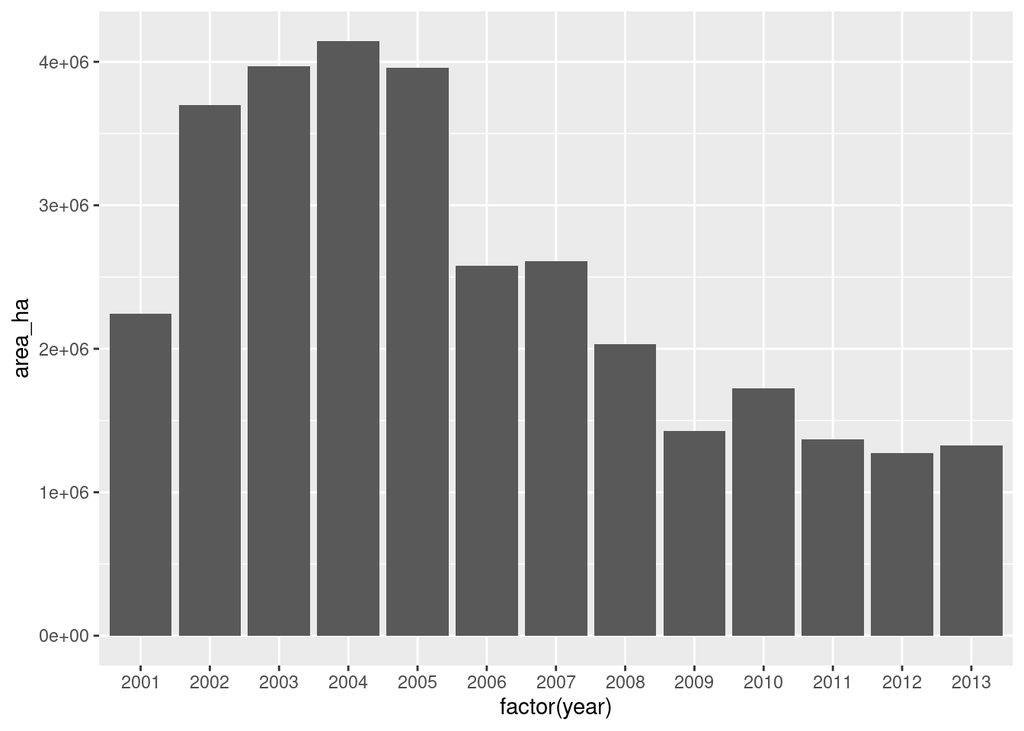

```r
# Write your answer here


#ggplot(brazil_loss_long, aes(y = area_ha)) +
#geom_bar(aes(x = factor(year)))


 brazil_loss_long %>%
  ggplot(aes(x = factor(year), y = area_ha)) +
  geom_col()
```

##### Same as the plot above but bar filled by the reasons for deforestation

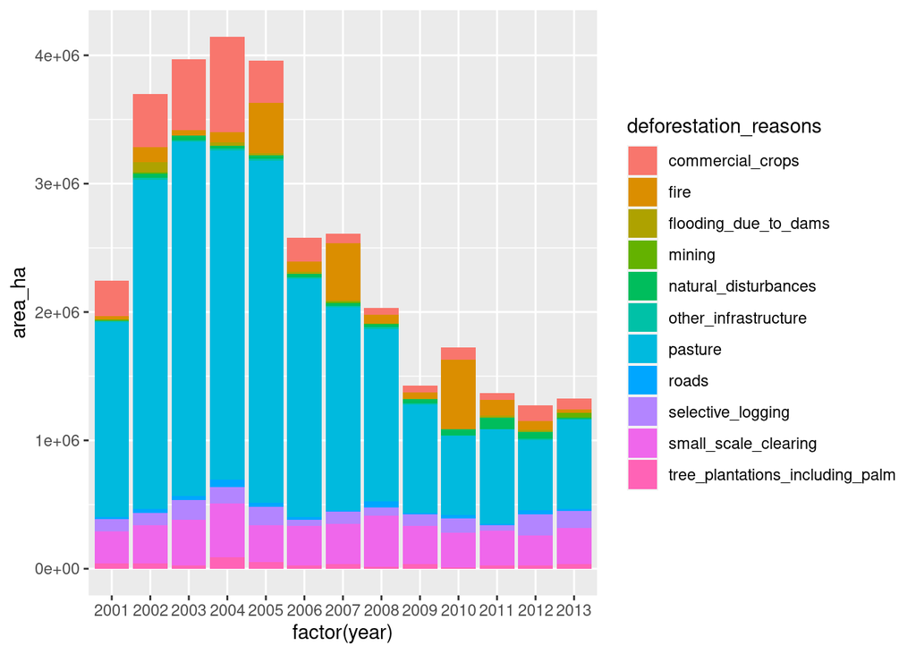

```r
# Write your answer here

brazil_loss_long %>%
  ggplot(aes(x = factor(year), y = area_ha,
             fill = deforestation_reasons)) +
  geom_col()
```

Even if we have too many categories, we can appreciate the amount of `natural_disturbances` versus the reasons induced by humans.

##### Lump the reasons for deforestations, keeping only the top 5 reasons, lumping as “Other” the rest

- The function `fct_lump()` is very useful for this operation. Be careful to weight the categories with the appropriate continuous variable.
- The legend of filled colours could be renamed and suppress if the title is explicit

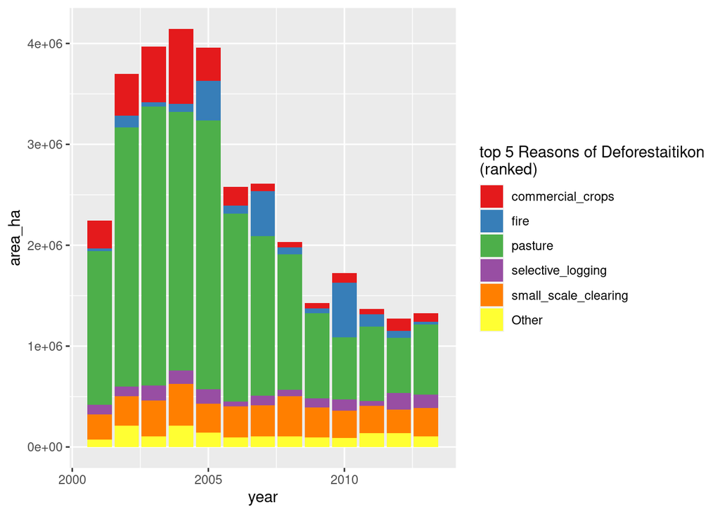

```r
# Write your answer here




brazil_loss_long %>%
ggplot(aes(x = year, y = area_ha,
           fill = fct_lump_n(factor(deforestation_reasons), 5, w = area_ha))) +
             #fct_infreq())) +
geom_col() +
scale_fill_brewer(palette = "Set1") +
labs(fill = "top 5 Reasons of Deforestaitikon\n(ranked)")
```

##### Optimize the previous plot by sorting the 5 main deforestation reasons

Unfortunately, `fct_infreq()` does not have a weight argument yet. You need then to take care of this manually.

One solution would be extract the top 5 main reasons using `dplyr` statements.

Then use this vector to recode the `reasons` with the reason name when part of the top5 or `other` if not. Then `fct_reorder(reasons2, area_ha)` does the correct reordering. You might want to use `fct_rev()` to have the sorting from top to bottom in the legend.

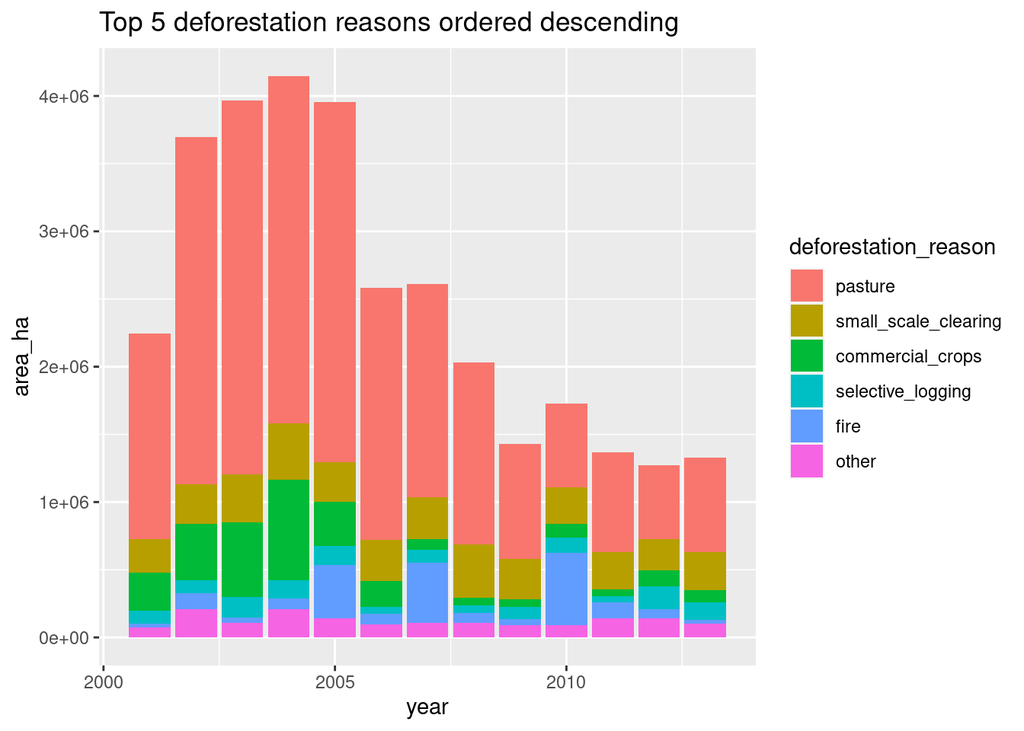

```r
# Write your answer here

#brazil_loss_long


brazil_loss_long %>%
  group_by(deforestation_reasons) %>%
  summarise(sum_area_ha = sum(area_ha, na.rm = TRUE)) %>%
  #arrange(desc(sum_area_ha)) %>%
  slice_max(order_by =sum_area_ha, n=5) %>%
  pull(deforestation_reasons) -> top5_reasons



brazil_loss_long %>%
  mutate(reasons = if_else(deforestation_reasons %in% top5_reasons,          deforestation_reasons, "other")) %>%
  ggplot(aes(x = year, y = area_ha, fill = fct_reorder(reasons, area_ha) %>% fct_rev())) +
  geom_col()+
  labs(title = "Top 5 deforestation reasons ordered descending", fill = "deforestation_reason")
```